# Supporting information 1: Comparing Single- and Repeated-visits occupancy

A simulation study

Valentin Lauret, Hélène Labach, Matthieu Authier, Olivier Gimenez

Supporting information 1 of article *Using single visits into integrated occupancy models to make the most of existing monitoring programs*.

Comparing single-visit and repeated-visits occupancy models. For details about single-visit occupancy modelling, refer to Lele et al. (2012) for its orginial formulation, and Peach et al. (2017) for extension to dynamic single-visit occupancy models.

# Methods

## Data simulation

Required packages

```r
library(R2jags)
library(tidyverse)
library(cowplot)
```

### State process

The occupancy state $z$ was drawn from a Bernoulli distribution with parameter $\psi$, $z \sim dbern(\psi)$. We wrote $\psi$ as a logistic function of an environmental covariate $\mbox{cov}$:

$$\mbox{logit}(\psi) = \alpha_{0} + \alpha_{1} \; \mbox{cov}$$

where $\alpha_{0}$ and $\alpha_{1}$ are unknown parameters that need to be estimated.

We considered 4 sets of values for the alpha’s:

We used the `sim_state_cov()` function to simulate the $z$ vector that contains the latent ecological state.

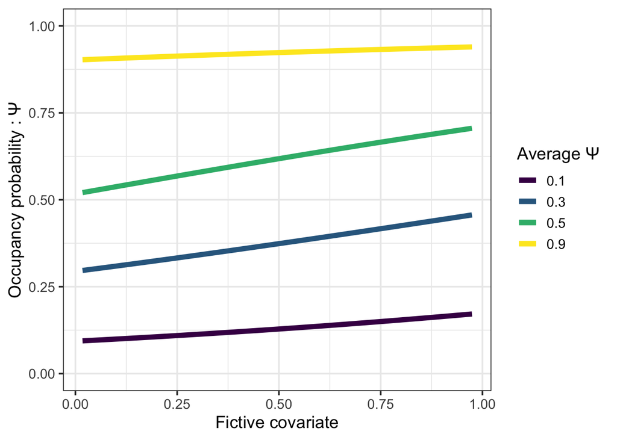

Fig.1: Occupancy probability as function of a fictive environmental covariate, 4 scenarii used for simulations

### Observation process

The observations are drawn either from a Bernoulli distribution with parameter $p$ or a multinomial distribution depending on two detection probabilities $p1$ and $p_2$ for the integrated occupancy model. We wrote $p$ as a logistic function of a sampling effort covariate $\mbox{seff}$:

$$\mbox{logit}(p) = \beta_{0} + \beta_{1} \; \mbox{seff}$$

where $\beta_{0}$ and $\beta_{1}$ are unknown parameters that need to be estimated.

We considered 4 sets of values for the beta’s:

We used the `sim_obs_cov()` function to simulate the $y$ vector that contains the detections/non-detections.

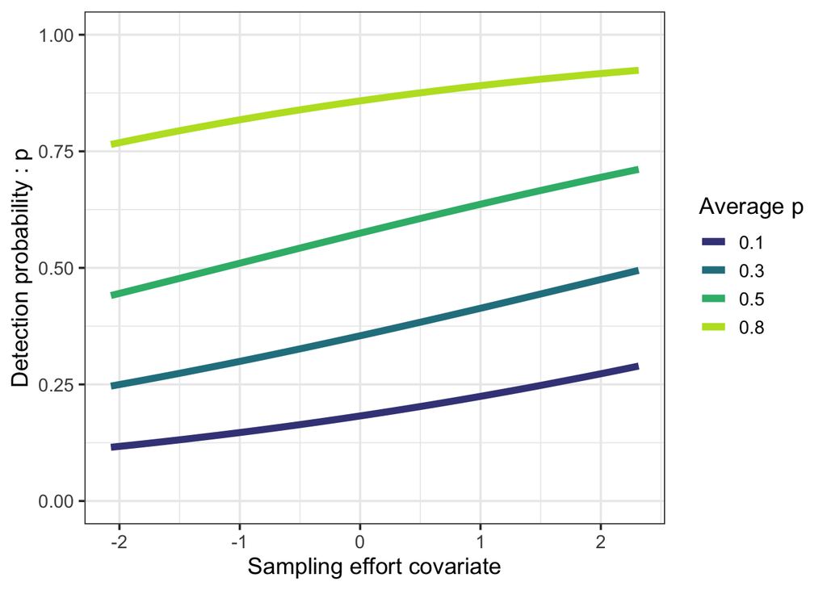

Fig.2: Detetion probability as function of a fictive sampling effort, 4 scenarii used for simulations

We simulated 4 different sampling occasions for repeated-visit occupancy. For single-visit occupancy, we formatted the data as described in the Methods section. For the sampling effort at site $i$, we summed the sampling effort over the 4 sampling occasions at site $i$, with `seff_sv <- apply(seff_rv,1,sum)`. For the detection/non-detection matrix, we considered the site as occupied if the species was detected at least once over the 4 sampling occasions, with `y_sv <- apply(y_rv,1,max)`.

### Study area

We simulated $z$ and $y$ for a study area of 100 sites.

## Models

For each combination of $\psi$ and $p$ we fitted 2 occupancy models:

- Repeated-visit occupancy model (RV)
- Single-visit occupancy model (SV)

We have 16 ecological situations depending on $\psi$ and $p$.

For each scenario, we ran 100 simulations and fitted the 2 occupancy models.

## Performances

To compare the performances of the different occupancy models we calculated the relative bias RB, and the root mean square error over the `S = 100` simulations :

- Relative bias: $RB = \frac{1}{S} \sum_{1}^{S} \frac{(\widehat{\theta}_{s}-\theta)}{\theta}$
- Root Mean Square Error: $RMSE = \sqrt{ \frac{1}{S} \sum_{1}^{S} (\widehat{\theta}_{s}-\theta)^2}$

## R codes

```r
# load function and data used

# load functionS
sim_state_cov <- function(nb_sites=nsites,init_occ = covparam, covenv = covenv){

  # define various quantities
  R = nb_sites # number of sites

  l.psi <- init_occ[1] + init_occ[2] * covenv + init_occ[3] * covenv * covenv
  psi1 <-  1 / ( 1 + exp( -l.psi ))# quadratic relation of the covariate with initial occupancy

  # pre-allocate memory
  site <- 1:R # Sites

  z <- array(dim = c(R)) # Expected and realized occurrence

  # define state process
  # first year/season
  z <- rbinom(R, 1, psi1) # Initial occupancy state


  return(z)
}
sim_obs_cov <- function(z=z, nb_occ = nocc,Seff, obsparam = obsparam){

  # define various quantities
  R = length(z) # number of sites
  K = nb_occ # number of occasions

  y <- array(NA, dim = c(R,K))
  p <- array(NA, dim = c(R,K))

  # define observation process

  for(i in 1:R){
    for(k in 1:K){

      l.p <- obsparam[1] + obsparam[2] * Seff[i,k] + obsparam[3] * Seff[i,k] * Seff[i,k]# quadratic relation of the covariate with initial occupancy

      p[i,k] <- ( 1 / ( 1 + exp(- l.p )))

      prob <- z[i] * p[i,k]
      y[i,k] <- rbinom(1,1, prob= prob)
    } #k
  } #i


  # format data
  return(y)
}
loopRVSV<- function(nsites, nocc, nsim, covparam, obsparam, Seff, Covenv){

  #### allocate memories for estimated parameters ####

  p_i <- rep(NA, nsim)
  psi_i <- rep(NA, nsim)

  bcov_i <- rep(NA, nsim)
  bseff_i <- rep(NA, nsim)

  p_ii <- rep(NA, nsim)
  psi_ii <- rep(NA, nsim)

  bcov_ii <- rep(NA, nsim)
  bseff_ii<- rep(NA, nsim)

  # allocate RMSE RB
  rbpsi_i    <- rep(NA, nsim)
  rmsepsi_i   <- rep(NA, nsim)
  rbcov_i     <- rep(NA, nsim)
  rmsecov_i <- rep(NA, nsim)
  rbp_i     <- rep(NA, nsim)
  rmsep_i    <- rep(NA, nsim)
  rbseff_i    <- rep(NA, nsim)
  rmseseff_i  <- rep(NA, nsim)

  rbpsi_ii    <- rep(NA, nsim)
  rmsepsi_ii  <- rep(NA, nsim)
  rbcov_ii    <- rep(NA, nsim)
  rmsecov_ii  <- rep(NA, nsim)
  rbp_ii      <- rep(NA, nsim)
  rmsep_ii    <- rep(NA, nsim)
  rbseff_ii   <- rep(NA, nsim)
  rmseseff_ii <- rep(NA, nsim)


  #### loop over nsim ####
  for( s in 1:nsim){
    print(s)

    # simulate datasets s

    z <- sim_state_cov(nb_sites = nsites, covenv= covenv, init_occ= covparam)
    y <- sim_obs_cov(z,nocc,Seff= Seff, obsparam= obsparam)

    p <- obsparam


# WITH Jags

    #### i = RV ####

    # Bundle data
    win.data <- list(y = y,nsite = dim(y)[1], nocc = dim(y)[2], Seff = Seff, covenv = covenv)

    # Initial values
    zst <- apply(y, 1, max) # Observed occurrence as inits for z

    # inits used for simulation
    psi = covparam[1]    # sum(z)/nsites
    p = obsparam[1]
    bcov <- covparam[2]
    bseff <- obsparam[2]

    inits <- function(){ list(z = zst, alpha.psi = psi, alpha.p= p, beta.cov = bcov, beta.seff= bseff)}

    # Parameters monitored
    params <- c( "alpha.p","alpha.psi", "beta.cov", "beta.qcov","beta.seff" ,"beta.qseff")

    ni <- 1000
    nc <-  1
    nb <- 200


    # Call JAGS from R (BRT 3 min)
    out <- jags(win.data, inits, params, "Occu_cov.jags", n.chains = nc, n.iter = ni, n.burnin = nb, working.directory = getwd())

     #head(out$BUGSoutput$summary)
     #denplot(out)
  #effectiveSize(as.mcmc(out))
    # intercept
    p_i[s] <- out$BUGSoutput$mean$alpha.p
    psi_i[s] <- out$BUGSoutput$mean$alpha.psi

    # slope linear estimate (Q: do we have to save the quadratic estimates-)

    bcov_i[s] <- out$BUGSoutput$mean$beta.cov
    bseff_i[s] <- out$BUGSoutput$mean$beta.seff

    #### ii = SV ####

    ysv <-  matrix(apply(y,1,max))

    Seffsv <- matrix(apply(Seff,1,sum))

    # Bundle data
    win.data <- list(y = ysv,nsite = dim(ysv)[1], nocc = dim(ysv)[2], Seff = Seff, covenv = covenv)

    # Initial values
    zst <- apply(ysv, 1, max)   # Observed occurrence as inits for z

    # inits used for simulation
    psi = covparam[1]    # sum(z)/nsites
    p = obsparam[1]
    bcov <- covparam[2]
    bseff <- obsparam[2]

    inits <- function(){ list(z = zst, alpha.psi = psi, alpha.p= p, beta.cov = bcov, beta.seff= bseff)}

    # Parameters monitored
    params <- c( "alpha.p","alpha.psi", "beta.cov", "beta.qcov","beta.seff" ,"beta.qseff")

    ni <- 1500
    nc <-   1
    nb <- 200


    # Call JAGS from R (BRT 3 min)
    out <- jags(win.data, inits, params, "Occu_cov.jags", n.chains = nc, n.iter = ni, n.burnin = nb, working.directory = getwd())

    # head(out$BUGSoutput$summary)
    # denplot(out)

    # intercept
    p_ii[s] <- out$BUGSoutput$mean$alpha.p
    psi_ii[s] <- out$BUGSoutput$mean$alpha.psi

    # slope linear estimate (Q: do we have to save the quadratic estimates-)

    bcov_ii[s] <- out$BUGSoutput$mean$beta.cov
    bseff_ii[s] <- out$BUGSoutput$mean$beta.seff

      # save --- RB & SE
    # i
    rbpsi_i[s]        <- (psi_i[s]-covparam[1])/covparam[1]   # RB alpha.psi
    rmsepsi_i[s]      <- (psi_i[s] - covparam[1])^2 # RMSE alpha.psi

    rbcov_i[s]        <- (bcov_i[s]-covparam[2])/covparam[2]   # RB cov
    rmsecov_i[s]      <- (bcov_i[s] - covparam[2])^2 # RMSE cov

    rbp_i[s]          <- (p_i[s]-obsparam[1])/obsparam[1]      # RB alpha p
    rmsep_i[s]        <- (p_i[s] - obsparam[1])^2 # RMSE alpha p

    rbseff_i[s]       <- (bseff_i[s]-obsparam[2])/obsparam[2]   # RB obs
    rmseseff_i[s]     <- (bseff_i[s] - obsparam[2])^2 # RMSE obs


    # ii
    rbpsi_ii[s]       <- (psi_ii[s]-covparam[1])/covparam[1]   # RB alpha.psi
    rmsepsi_ii[s]     <- (psi_ii[s] - covparam[1])^2 # RMSE alpha.psi

    rbcov_ii[s]       <- (bcov_ii[s]-covparam[2])/covparam[2]   # RB cov
    rmsecov_ii[s]     <- (bcov_ii[s] - covparam[2])^2 # RMSE cov

    rbp_ii[s]         <- (p_ii[s]-obsparam[1])/obsparam[1]       # RB alpha p
    rmsep_ii[s]       <- (p_ii[s] - obsparam[1])^2 # RMSE alpha p

    rbseff_ii[s]      <- (bseff_ii[s]-obsparam[2])/obsparam[2]   # RB obs
    rmseseff_ii[s]    <- (bseff_ii[s] - obsparam[2])^2 # RMSE obs


  } # end for



  para <- data.frame("nsites" = nsites,"nocc" =  nocc, "nsim" = nsim, "covparam"= covparam, "obsparam"= obsparam)

  return(list(para = para, # i
              rbpsi_i = rbpsi_i,
              rmsepsi_i = rmsepsi_i,
              rbcov_i = rbcov_i,
              rmsecov_i = rmsecov_i,
              rbp_i = rbp_i,
              rmsep_i = rmsep_i,
              rbseff_i = rbseff_i,
              rmseseff_i = rmseseff_i,
              # = #,
              rbpsi_ii = rbpsi_ii,
              rmsepsi_ii = rmsepsi_ii,
              rbcov_ii = rbcov_ii,
              rmsecov_ii = rmsecov_ii,
              rbp_ii = rbp_ii,
              rmsep_ii = rmsep_ii,
              rbseff_ii = rbseff_ii,
              rmseseff_ii = rmseseff_ii))

} # endfunction
```

```r
# run the analysis
# load param for logistic regressions
nsites = 100
# occupancy
covparam.3 <- c(-0.5,0.2,0) # psi = 0.3
covparam.1 <- c(-1.9,0.2,0) # psi = 0.1
covparam.5 <- c(0.5,0.23,0) # psi = 0.5
covparam.9 <- c(2.5,0.15,0) # psi = 0.9

covparam <- list(covparam.1 =  covparam.1,
                 covparam.3 =  covparam.3,
                 covparam.5 =  covparam.5,
                 covparam.9 <- covparam.9)

# detection
obsparam.5 <- c(0.3,0.26,0)  # p = 0.5
obsparam.8 <- c(1.8,0.3,0)   # p = 0.8
obsparam.1 <- c(-1.5,0.26,0) # p = 0.1
obsparam.3 <- c(-0.6,0.25,0) # p = 0.3

obsparam <- list(obsparam.1 <- obsparam.1,
                 obsparam.3 <- obsparam.3,
                  obsparam.5 <- obsparam.5,
                 obsparam.8 <- obsparam.8)

# run the analysis
# generate covariate values

  Seff <- data.frame(cbind(rnorm(nsites),rnorm(nsites),rnorm(nsites),rnorm(nsites)))

  Covenv <- covenv <- runif(nsites,0,1)

  res <- list()
  i <- 0
  t <- proc.time()
 for(c in 1: length(covparam)){  #i <- i+1

   for(o in 1:length(obsparam)){
    i <- i+1

   print(paste("obs",o))
   print(paste("cov",c))
   res[[i]] <- loopRVSV(nsites = nsites, nocc = nocc, nsim = nsim, covparam = covparam[[c]], obsparam[[o]], Seff, Covenv)


   }# end o
   } # end c

  run.time <- proc.time() - t
#
# ------ save results if you want
save(res,run.time, file ="simRVSV.Rdata")
```

# Results

## Covariate effect size

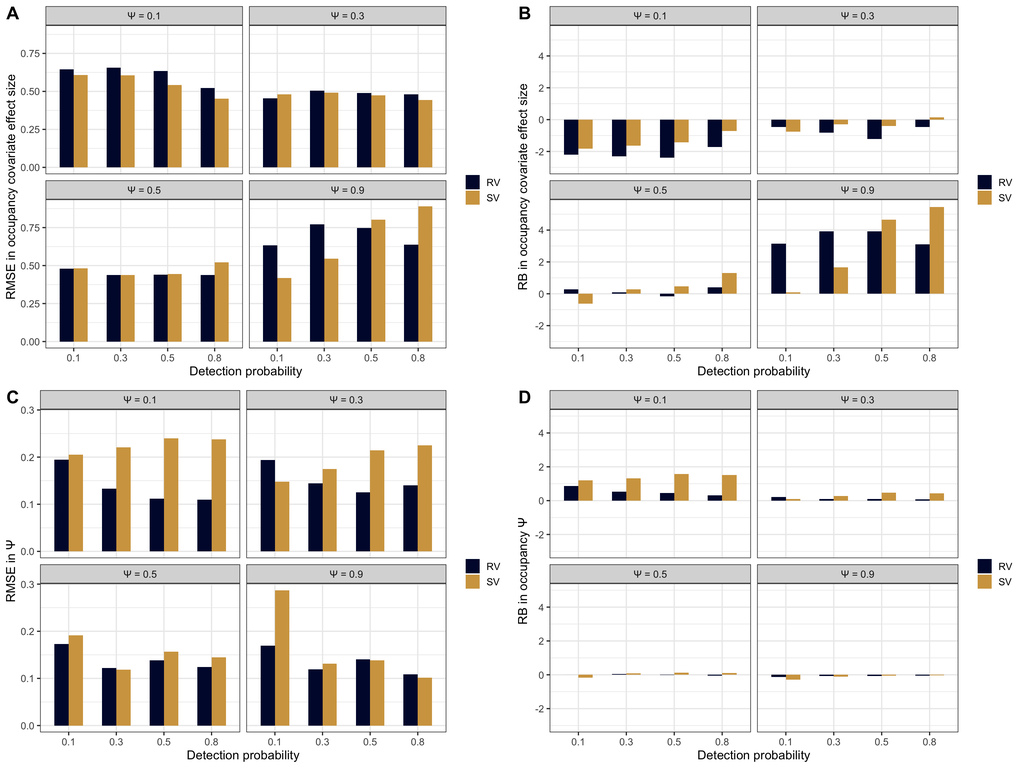

Fig. 3: RMSE and RB for all occupancy models

## Occupancy prediction

Predicted occupancy probability between single- and repeated-visits models are closed to each other in Fig. 3C-D. However, precision and bias are greater for low occupancy $\psi = 0.1$, which is consistent with Peach et al. (2017) findings. Same results when detection probability is low and when $\psi$ is high. Although, note that RMSE plotting scale is different between Fig. 3A and 3C.

# Discussion

Our simulations study showed that single-visit and repeated-visit occupancy models had similar results in the estimation of covariate effect size for ocucpancy. We explored simple logistic regressions to describe models paramters. To be consistent with our manuscript, we reported performances of covariates effect size and predicted occupancy. To have a complete understanding of models performances, one might want to look at wider range of relationships, and observe all models parameters (e.g. intercept, sampling effort effect size on detection probability).

# References

Lele, S. R., Moreno, M., & Bayne, E. (2012). Dealing with detection error in site occupancy surveys: What can we do with a single survey? In *Journal of Plant Ecology* (Nos. 1; Vol. 5, pp. 22–31). https://doi.org/10.1093/jpe/rtr042

Peach, M. A., Cohen, J. B., & Frair, J. L. (2017). Single-visit dynamic occupancy models: An approach to account for imperfect detection with Atlas data. In *Journal of Applied Ecology* (Nos. 6; Vol. 54, pp. 2033–2042). https://doi.org/10.1111/1365-2664.12925